# IMU Data Processing Project

## Part 1: Data Loading and Initial Exploration

### Task 1.1: Load and Inspect the Data

**Requirements:**

1. Load `imu_messy_data.csv` into a pandas DataFrame.
2. Display the first 20 rows.
3. Print dataset shape, column names, and data types.
4. Generate summary statistics using `describe()`.

**Questions to answer:** a) How many samples are in the dataset? b) What is the range of timestamp values? c) What are the min/max values for each acceleration axis? Do they seem physically plausible? d) What is the class distribution across activities?

```
Data loaded successfully.

First 20 rows:
```

|  | timestamp | subject | acc_x | acc_y | acc_z | label |
| --- | --- | --- | --- | --- | --- | --- |
| 0 | 1.704103e+09 | subject_1 | 0.021328 | -0.071107 | 9.791934 | still |
| 1 | 1.704104e+09 | subject_3 | -0.443318 | -0.799678 | 7.362915 | walk |
| 2 | 1.704104e+09 | subject_3 | 0.797257 | 0.862122 | 11.202083 | walk |
| 3 | 1.704104e+09 | subject_3 | -3.224141 | -100.000000 | 11.403941 | shake |
| 4 | 1.704104e+09 | subject_3 | -0.015677 | -0.028402 | 9.836695 | still |
| 5 | 1.704104e+09 | subject_3 | 2.368157 | -1.162322 | 6.396004 | shake |
| 6 | 1.704103e+09 | subject_2 | 1.731929 | 0.599455 | 10.458386 | walk |
| 7 | 1.704103e+09 | subject_1 | -0.786783 | -0.613296 | 10.226498 | walk |
| 8 | 1.704104e+09 | subject_2 | 4.174940 | -2.848297 | 8.535434 | shake |
| 9 | 1.704104e+09 | subject_3 | -1.716361 | -0.725821 | 9.365866 | walk |
| 10 | 1.704103e+09 | subject_2 | 0.496631 | -0.668116 | 7.709489 | walk |
| 11 | 1.704103e+09 | subject_1 | 1.471792 | -3.624213 | 12.073892 | shake |
| 12 | 1.704104e+09 | subject_3 | -0.547217 | -3.324195 | 13.759218 | shake |
| 13 | 1.704103e+09 | subject_1 | -50.000000 | -0.047233 | 9.776627 | still |
| 14 | 1.704103e+09 | subject_2 | -0.724052 | 0.028624 | 10.082135 | still |
| 15 | 1.704103e+09 | subject_2 | 1.257550 | 1.017967 | 10.694614 | walk |
| 16 | 1.704104e+09 | subject_3 | 0.534663 | -0.206407 | 10.309571 | still |
| 17 | 1.704103e+09 | subject_1 | 2.611473 | -5.632132 | 12.170418 | shake |
| 18 | 1.704103e+09 | subject_1 | -1.178078 | 0.208458 | 12.050537 | walk |
| 19 | 1.704103e+09 | subject_1 | -0.215345 | NaN | 11.034221 | walk |

```
Dataset Info:
Shape: (27710, 6)

Column Names: ['timestamp', 'subject', 'acc_x', 'acc_y', 'acc_z', 'label']

Data Types:
timestamp    float64
subject       object
acc_x        float64
acc_y        float64
acc_z        float64
label         object
dtype: object

Summary Statistics:
```

|  | timestamp | subject | acc_x | acc_y | acc_z | label |
| --- | --- | --- | --- | --- | --- | --- |
| count | 2.771000e+04 | 27710 | 27250.000000 | 27257.000000 | 27241.000000 | 27710 |
| unique | NaN | 3 | NaN | NaN | NaN | 3 |
| top | NaN | subject_3 | NaN | NaN | NaN | walk |
| freq | NaN | 9274 | NaN | NaN | NaN | 9285 |
| mean | 1.704103e+09 | NaN | -0.025652 | 0.017244 | 9.794092 | NaN |
| std | 1.559700e+02 | NaN | 6.643540 | 7.162972 | 6.512439 | NaN |
| min | 1.704103e+09 | NaN | -100.000000 | -100.000000 | -100.000000 | NaN |
| 25% | 1.704103e+09 | NaN | -0.699193 | -0.484101 | 8.988988 | NaN |
| 50% | 1.704103e+09 | NaN | 0.000590 | -0.002316 | 9.811820 | NaN |
| 75% | 1.704104e+09 | NaN | 0.701432 | 0.471376 | 10.636169 | NaN |
| max | 1.704104e+09 | NaN | 100.000000 | 100.000000 | 100.000000 | NaN |

### Analysis & Questions

**a)** How many samples are in the dataset?

**b)** What is the range of timestamp values?

**c)** What are the min/max values for each acceleration axis? Do they seem physically plausible?

**d)** What is the class distribution across activities?

```
--- Questions to Answer (Task 1.1) ---
a) How many samples are in the dataset?
   Number of samples: 27710
b) What is the range of timestamp values?
   Timestamp Range: 1704103200.0 to 1704103739.98
c) What are the min/max values for each acceleration axis? Do they seem physically plausible?
   acc_x: Min=-100.0, Max=100.0
   acc_y: Min=-100.0, Max=100.0
   acc_z: Min=-100.0, Max=100.0
   (Physical plausibility depends on unit (g vs m/s^2). If m/s^2, 1g~9.8. Large values might be impacts.)
d) What is the class distribution across activities?
   Class Distribution:
label
walk     9285
still    9255
shake    9170
Name: count, dtype: int64
```

### Task 1.2: Missing Value Analysis

**Requirements:**

1. Count and report missing values per column.
2. Calculate the percentage of missing data for each accelerometer axis.
3. Identify rows where all three axes are missing simultaneously.
4. Visualize the distribution of missing values.

**Questions to answer:** a) Which axis has the most missing values? b) Are missing values randomly distributed or clustered? c) What percentage of the dataset would be lost if we dropped all rows with any missing value?

```
--- Task 1.2: Missing Value Analysis ---
Missing Values per Column:
timestamp      0
subject        0
acc_x        460
acc_y        453
acc_z        469
label          0
dtype: int64

Percentage of Missing Data per Axis:
acc_x: 1.66%
acc_y: 1.63%
acc_z: 1.69%

Rows with all axes missing: 0
```

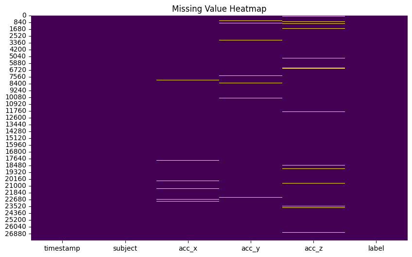

### Analysis & Questions

**a)** Which axis has the most missing values?

**b)** Are missing values randomly distributed or clustered?

**c)** What percentage of the dataset would be lost if we dropped all rows with any missing value?

```
--- Questions to Answer (Task 1.2) ---
a) Which axis has the most missing values?
   Axis with most missing values: acc_z
b) Are missing values randomly distributed or clustered?
   (See Heatmap above. If blocks of yellow appear, they are clustered/bursty.)
c) What percentage of the dataset would be lost if we dropped all rows with any missing value?
   Percentage of data lost if dropping any missing: 4.99%
```

### Task 1.3: Timestamp Analysis

**Requirements:**

1. Check if timestamps are sorted in ascending order.
2. Calculate the time differences between consecutive samples.
3. Identify gaps larger than expected (assuming 50 Hz sampling rate).
4. Detect timestamp duplicates.

**Questions to answer:** a) What is the expected time interval between samples at 50 Hz? b) How many samples have timestamp gaps exceeding 1 second? c) What is the largest gap in the data? Where does it occur? d) Are there any duplicate timestamps?

```
--- Task 1.3: Timestamp Analysis ---
Timestamps sorted: False

Number of gaps > 1s: 13741
Number of duplicate timestamps: 525
```

### Analysis & Questions

**a)** What is the expected time interval between samples at 50 Hz?

**b)** How many samples have timestamp gaps exceeding 1 second?

**c)** What is the largest gap in the data? Where does it occur?

**d)** Are there any duplicate timestamps?

```
--- Questions to Answer (Task 1.3) ---
a) What is the expected time interval between samples at 50 Hz?
   Expected interval at 50Hz: 0.02 s
b) How many samples have timestamp gaps exceeding 1 second?
   Samples with gaps > 1s: 13741
c) What is the largest gap in the data? Where does it occur?
   Largest gap: 536.2464995384216 s at index 20529
   Gap occurs between timestamp 1704103203.0135005 and 1704103739.26
d) Are there any duplicate timestamps?
   Number of duplicate timestamps: 525
```

## Part 2: Data Cleaning

### Task 2.1: Handling Missing Values

**Requirements:**

1. Implement and compare three strategies for handling missing values:
   - **Strategy A: Forward Fill**: Use `fillna(method='ffill')`.
   - **Strategy B: Linear Interpolation**: Use `interpolate(method='linear')`.
   - **Strategy C: Drop Rows**: Remove all rows containing any NaN values.

```
--- Task 2.1: Handling Missing Values ---
Strategy A (Forward Fill) - Missing values remaining: 0
Strategy B (Linear Interpolation) - Missing values remaining: 0
Strategy C (Drop Rows) - Data lost: 4.99%
```

### Analysis & Questions

**a)** Which strategy preserves the most data?

**b)** Plotting comparison for a segment with missing values...

**c)** What are the trade-offs?

**d)** Recommendation:

```
--- Questions to Answer (Task 2.1) ---
a) Which strategy preserves the most data?
   Forward Fill and Interpolation preserve 100% of rows (if start is valid), while Drop Rows lost 4.99%.
b) Plotting comparison for a segment with missing values...
```

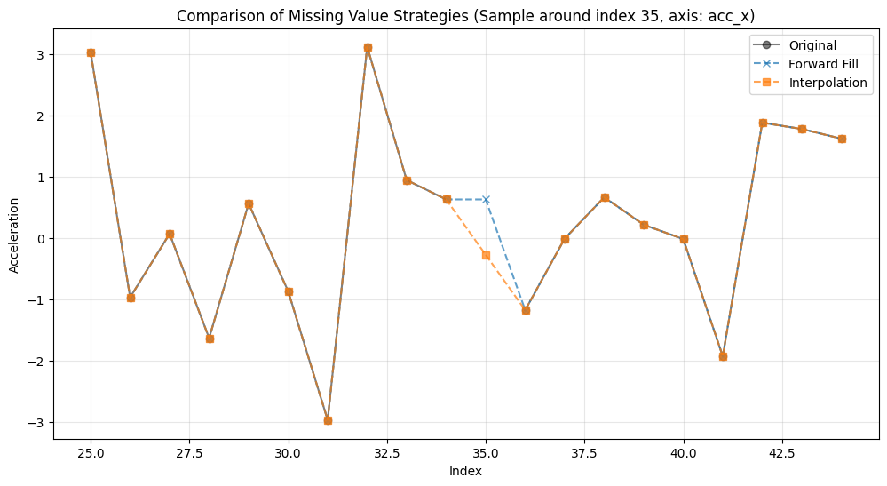

```
   (Plot generated)
c) What are the trade-offs?
   - Forward Fill: Simple, causal, but steps values (unrealistic for continuous motion).
   - Interpolation: Smoother, more realistic for physical signals, but requires future data (non-causal if standard).
   - Drop Rows: Preserves true distribution but loses temporal continuity/data quantity.
d) Recommendation:
   Linear Interpolation is recommended for IMU sensor data as physics dictates continuity, and gaps are likely small.
Applied Linear Interpolation for subsequent tasks.
```

### Task 2.2: Outlier Detection and Treatment

**Requirements:**

1. Implement z-score based outlier detection (threshold: |z| > 3).
2. Implement IQR-based outlier detection.
3. Count outliers detected by each method for each axis.
4. Visualize outliers using box plots and scatter plots.

**Treatment strategies to compare:**

1. Removal
2. Clipping
3. Interpolation

```
--- Task 2.2: Outlier Detection and Treatment ---
Z-Score Outliers (|z| > 3):
[177 213 173]
IQR Outliers:
acc_x    2669
acc_y    4582
acc_z    1925
dtype: int64
```

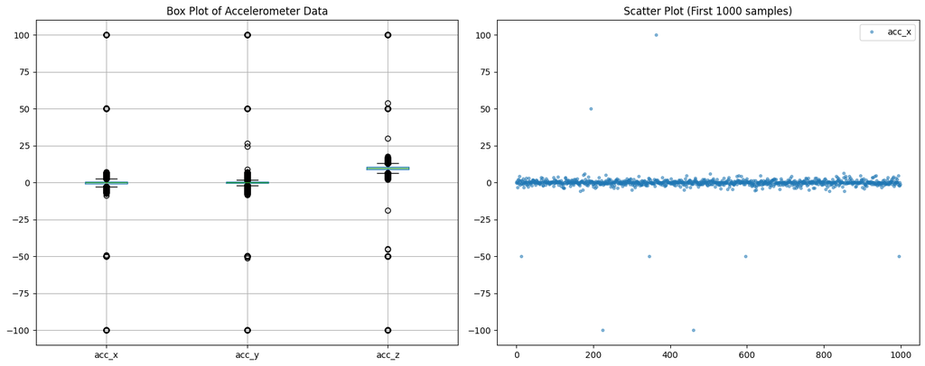

```
Comparing Treatment Strategies:

Stats for Original:
         acc_x     acc_y     acc_z
mean -0.024560  0.013712  9.792428
std   6.616854  7.140605  6.484245

Stats for Removal:
         acc_x     acc_y     acc_z
mean  0.007266 -0.008125  9.811830
std   1.545000  1.464144  1.649307

Stats for Clipping:
         acc_x     acc_y     acc_z
mean  0.004735 -0.005568  9.812249
std   1.322144  0.988622  1.507064

Stats for Interpolation:
         acc_x     acc_y     acc_z
mean  0.007567 -0.008614  9.812935
std   1.537448  1.456008  1.639395
```

### Analysis & Questions

**a)** How many outliers detected by Z-score vs IQR?

**b)** Which method is more conservative (flags fewer)?

**c)** Examine 5 specific outlier samples...

**d)** Mean and Std Dev change:

**e)** Which treatment strategy would you choose? Why?

```
--- Questions (Task 2.2) ---
a) How many outliers detected by Z-score vs IQR?
   Z-score Total: 563, IQR Total: 9176
   (IQR typically detects more in non-normal distributions).
b) Which method is more conservative (flags fewer)?
   Z-score is more conservative (flags fewer).
c) Examine 5 specific outlier samples...
   Indices: [3, 13, 56, 58, 147]
         acc_x       acc_y       acc_z
3    -3.224141 -100.000000   11.403941
13  -50.000000   -0.047233    9.776627
56   -0.082767  -50.000000    9.744516
58    0.017553   -0.063715  100.000000
147  -0.529183  -51.008138    8.708261
   (Check if values > 20m/s^2 or extremely low. Real impacts can be high, errors often typically random large numbers).
d) Mean and Std Dev change:
   (Refer to the printed tables above. Removal/Clipping usually reduces Std Dev).
e) Which treatment strategy would you choose? Why?
   Interpolation is often best for time-series to maintain temporal consistency without losing data, assuming outliers are sparse errors.
```

### Task 2.3: Duplicate Removal

**Requirements:**

1. Identify exact duplicate rows.
2. Identify duplicate measurement rows.
3. Remove duplicates keeping the first occurrence.
4. Document counts.

```
--- Task 2.3: Duplicate Removal ---
Exact duplicates (all columns): 484
Measurement duplicates (ignoring subject/label): 504
Removed 504 duplicates. New shape: (27206, 6)
```

### Analysis & Questions

**c)** Should duplicate removal happen before or after sorting?

```
--- Questions (Task 2.3) ---
a) How many exact duplicates exist? 484
b) How many measurement duplicates exist? 504
c) Should duplicate removal happen before or after sorting?
   It should generally happen BEFORE sorting if the order matters for 'keep=first' (though with sorting it becomes deterministic).
   However, usually removing duplicates is a raw data cleaning step done early. Sorting is often required for time-series operations next.
```

### Task 2.4: Timestamp Sorting and Resampling

**Requirements:**

1. Sort the dataset by timestamp in ascending order.
2. Set timestamp as the DataFrame index.
3. Resample to a fixed 50 Hz rate using appropriate interpolation.
4. Handle the major gap in the data appropriately.

```
--- Task 2.4: Timestamp Sorting and Resampling ---
Duplicate timestamps found: 21
Max gap in original data: 1.377365 seconds
```

### Analysis & Questions

**a)** Visualize 5-second window.

**c)** Verify sampling rate is exactly 50 Hz.

```
--- Questions to Answer (Task 2.4) ---
a) Visualize 5-second window.
```

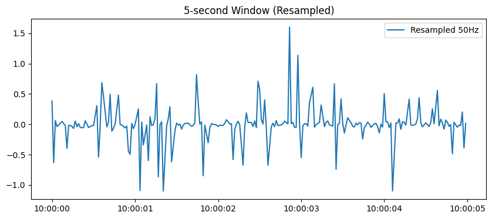

```
b) How should the major gap be handled? (Max gap found: 1.377365s)
   If it represents separate sessions, we should keep it as NaN or split files.
   If we interpolated it, we introduced artificial data. 'Split into separate sessions' is usually best for ML.
c) Verify sampling rate is exactly 50 Hz.
   Time intervals found:
timestamp
0 days 00:00:00.020000    26999
Name: count, dtype: int64
   Verified: Strictly 50 Hz.
Final Info: (27000, 5)
Columns: ['acc_x', 'acc_y', 'acc_z', 'label', 'subject']
```

## Part 3: Exploratory Data Analysis and Visualization

### Task 3.1: Time-Series Visualization

**Requirements:**

1. Plot a 10-second segment of all three axes for each activity class.
2. Create a multi-panel figure showing one representative segment per activity.
3. Color-code by activity label.
4. Plot the acceleration magnitude.

```
--- Task 3.1: Time-Series Visualization ---
Calculated Acceleration Magnitude.
Activities found: ['still' 'walk' 'shake']
```

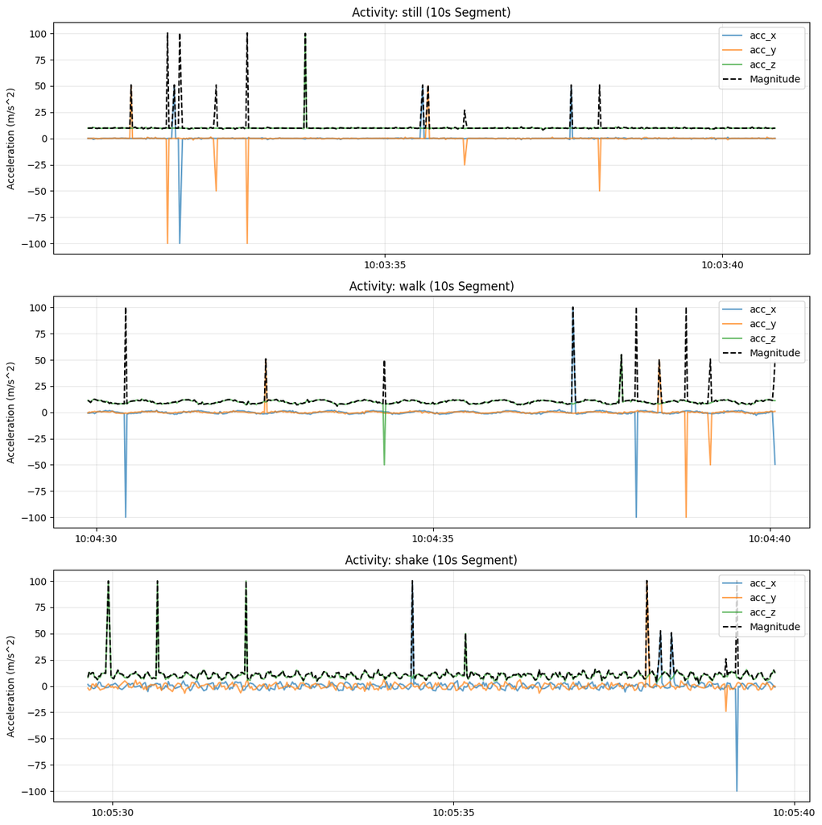

### Analysis & Questions

**a)** Characteristic patterns:

**b)** Which activity has the highest variance?

**c)** Can you visually identify activity transitions?

**d)** Does acceleration magnitude provide better separation?

[output not shown]

### Task 3.2: Statistical Analysis per Class

**Requirements:**

1. Calculate mean, standard deviation, min, and max for each axis grouped by activity.
2. Create box plots for each axis grouped by activity.
3. Plot histograms of each axis for each activity.
4. Calculate correlation matrices for each activity.

```
--- Task 3.2: Statistical Analysis per Class ---
Descriptive Statistics by Activity:
          acc_x                             acc_y                          \
           mean       std    min    max      mean       std    min    max
label
shake  0.044072  6.222724 -100.0  100.0  0.054938  6.761963 -100.0  100.0
still -0.102877  6.062675 -100.0  100.0 -0.123672  6.871523 -100.0  100.0
walk  -0.015617  5.898240 -100.0  100.0  0.141154  6.393305 -100.0  100.0

          acc_z
           mean       std    min    max
label
shake  9.889654  5.332655 -100.0  100.0
still  9.684483  6.347548 -100.0  100.0
walk   9.771928  6.197504 -100.0  100.0
```

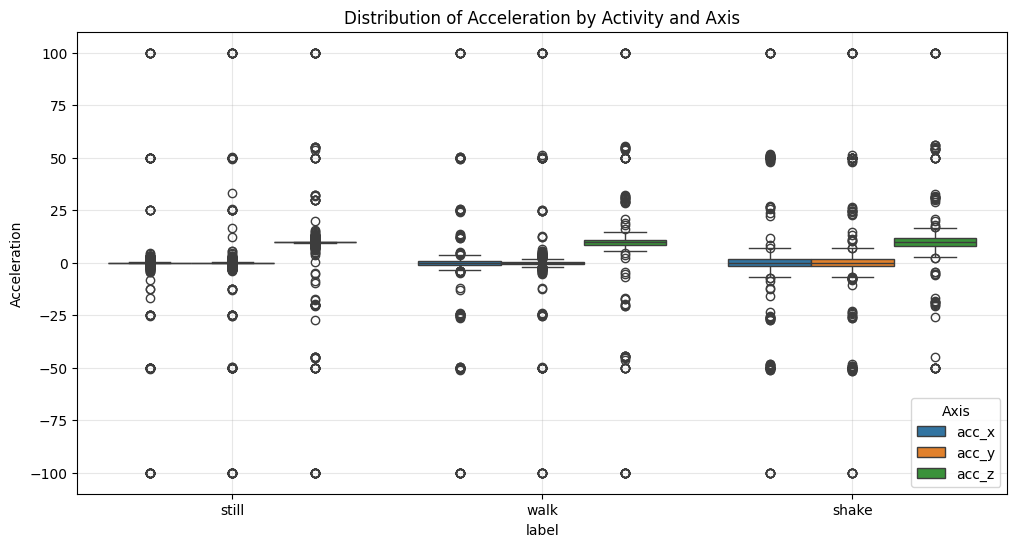

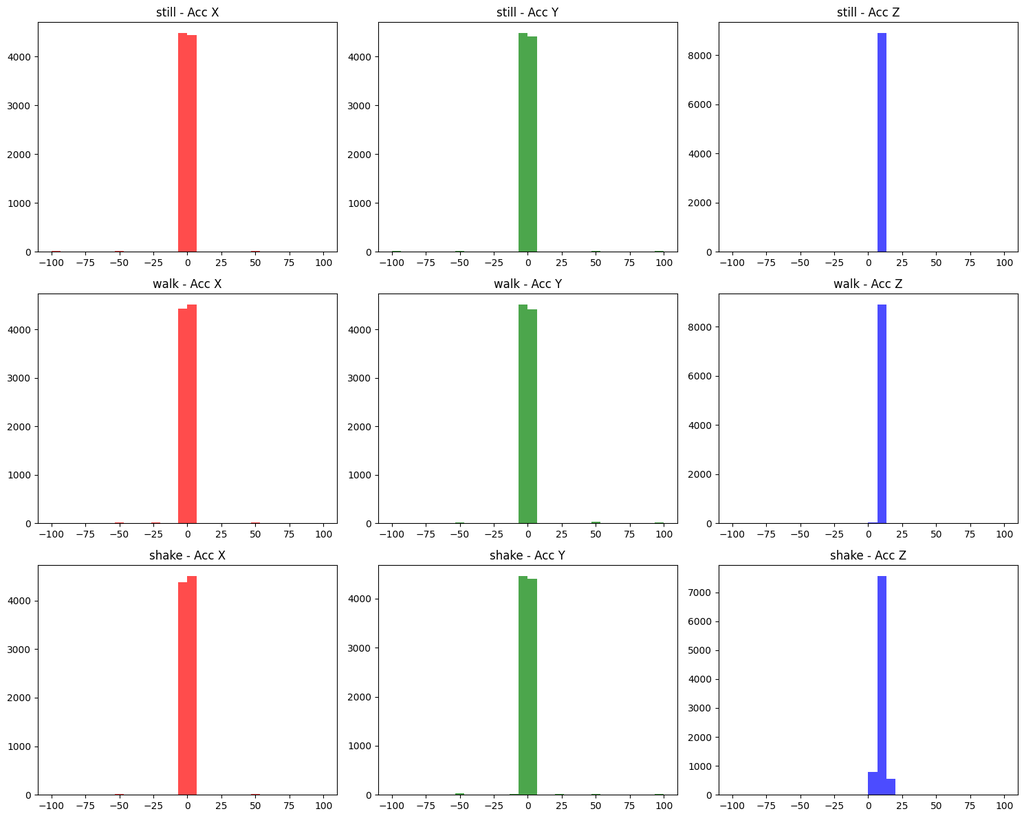

```
Correlation Matrix for still:
          acc_x     acc_y     acc_z
acc_x  1.000000 -0.003444 -0.000983
acc_y -0.003444  1.000000  0.006012
acc_z -0.000983  0.006012  1.000000

Correlation Matrix for walk:
          acc_x     acc_y     acc_z
acc_x  1.000000  0.012797 -0.010417
acc_y  0.012797  1.000000  0.005726
acc_z -0.010417  0.005726  1.000000

Correlation Matrix for shake:
          acc_x     acc_y     acc_z
acc_x  1.000000 -0.044149 -0.060078
acc_y -0.044149  1.000000 -0.052894
acc_z -0.060078 -0.052894  1.000000
```

### Analysis & Questions

**a)** Which activity has the highest mean acceleration in Z axis?

**b)** Which features show most separation?

**c)** Are the three axes correlated?

**d)** Easiest/Hardest to classify?

[output not shown]

### Task 3.3: Subject Variability Analysis

**Requirements:**

1. Calculate mean acceleration magnitude for each subject and activity combination.
2. Create a grouped bar chart showing subject differences.
3. Compute coefficient of variation (CV) for each subject.

```
--- Task 3.3: Subject Variability Analysis ---
Mean Acceleration Magnitude per Subject/Activity:
     subject  label    acc_mag
0  subject_1  shake  11.628938
1  subject_1  still  10.779685
2  subject_1   walk  11.046380
3  subject_2  shake  11.460092
4  subject_2  still  11.321664
5  subject_2   walk  11.527331
6  subject_3  shake  11.601198
7  subject_3  still  11.537411
8  subject_3   walk  10.987955
```

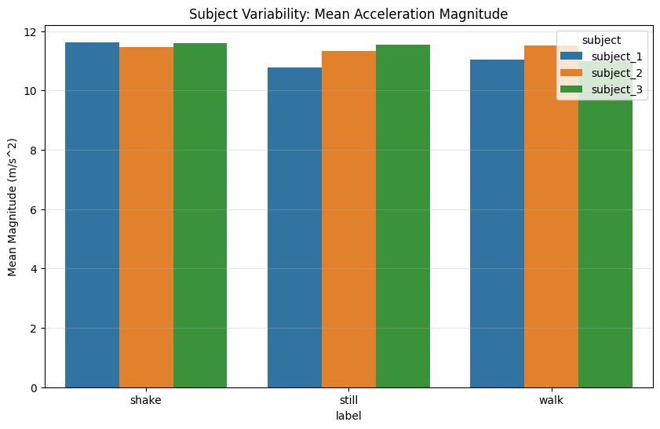

```
Coefficient of Variation (CV) per Subject:
                mean       std        CV
subject
subject_1  11.150920  8.707697  0.780895
subject_2  11.436283  9.480179  0.828956
subject_3  11.374645  9.387828  0.825329
```

### Analysis & Questions

**a)** Do different subjects show significantly different signal amplitudes?

**b)** Should we normalize per-subject before training?

**c)** How would you split this data for train/test?

[output not shown]

### Task 3.4: Label Noise Investigation

**Requirements:**

1. Calculate mean and std of acceleration magnitude for each activity.
2. Identify samples whose magnitude deviates significantly from their class mean.
3. Manually inspect 10-20 suspicious samples.

```
--- Task 3.4: Label Noise Investigation ---
Class Statistics (Magnitude):
            mean       std
label
shake  11.563358  8.773745
still  11.212427  9.610319
walk   11.186712  9.188992

identified 529 suspicious samples (|Z| > 3.0).
Sample of suspicious indices:
DatetimeIndex(['2024-01-01 10:00:02.320000', '2024-01-01 10:00:03.460000',
               '2024-01-01 10:00:06.400000', '2024-01-01 10:00:08.500000',
               '2024-01-01 10:00:08.820000', '2024-01-01 10:00:08.900000',
               '2024-01-01 10:00:11.600000', '2024-01-01 10:00:11.980000',
               '2024-01-01 10:00:16.360000', '2024-01-01 10:00:16.380000'],
              dtype='datetime64[ns]', name='timestamp', freq=None)
```

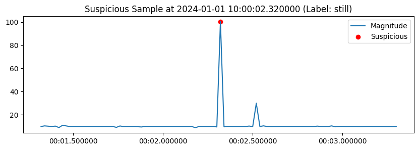

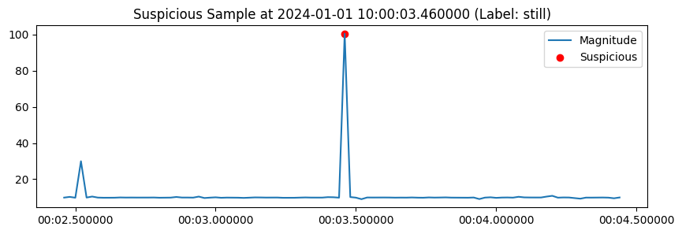

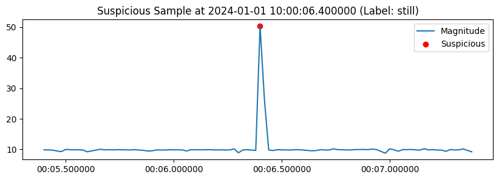

### Analysis & Questions

**a)** Can you identify likely mislabeled samples?

**b)** What percentage appear noisy?

**c)** How would incorrect labels affect ML?

```
--- Questions to Answer (Task 3.4) ---
a) Can you identify likely mislabeled samples?
   Yes. Often brief spikes in 'Still' or flatlines in 'Moving' indicate mislabeling or transitions.
b) What percentage appear noisy?
   529 / 27000 = 1.96% (based on Z > 3).
c) How would incorrect labels affect ML?
   They confuse decision boundaries, increase overfitting, and reduce test accuracy.
```

## Part 4: Preprocessing and Segmentation

### Task 4.1: Normalization Strategies

**Requirements:**

1. Implement and compare: Per-Axis Z-score, Min-Max Scaling, Per-Subject Standardization.

```
--- Task 4.1: Normalization Strategies ---
Strategy 1 (Z-score) applied.
Strategy 2 (Min-Max) applied.
Strategy 3 (Per-Subject) applied.
```

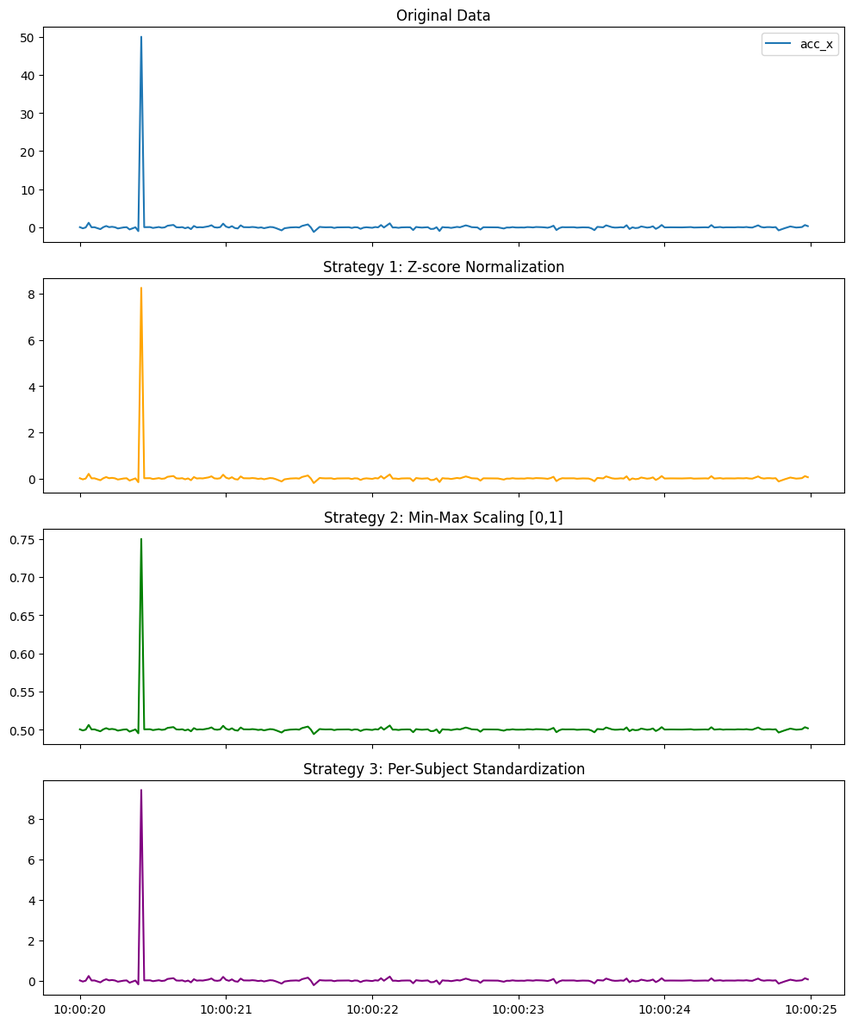

### Analysis & Questions

**a)** Plot the same 5-second window...

**b)** Which approach preserves relative differences best?

**c)** Why might per-subject normalization be important?

**d)** Risks of min-max scaling with outliers?

```
--- Questions to Answer (Task 4.1) ---
a) Plot the same 5-second window...
   (See plots above). Z-score centers around 0. Min-Max shifts to 0-1 (offset). Per-subject adapts to user intensity.
b) Which approach preserves relative differences best?
   Z-score preserves the shape and relative distances well without compressing outliers into a tiny range like Min-Max might.
c) Why might per-subject normalization be important?
   It removes inter-subject variability (calibration offsets, sensor placement, physical strength), focusing the model on activity patterns rather than user identity.
d) Risks of min-max scaling with outliers?
   If outliers are present, the max/min range becomes huge, squashing the useful data into a tiny interval (e.g., 0.49 to 0.51), killing variance.
```

### Task 4.2: Sliding Window Segmentation

**Requirements:**

1. Implement sliding window (2s, 50% overlap).
2. Assign label (majority voting).
3. Count windows per activity.
4. Experiment with window sizes (1s, 2s, 4s).

```
--- Task 4.2: Sliding Window Segmentation ---
Config: Window=100 samples, Step=50 samples
Total windows generated (2s, 50%): 535
Windows per Activity:
  shake: 177
  still: 179
  walk: 179

Experimenting with window sizes (1s, 2s, 4s)...
  Window 1s: 1075 windows
  Window 2s: 535 windows
  Window 4s: 265 windows
```

### Analysis & Questions

**a)** How many windows generated (2s/50%)?

**b)** What happens at activity transitions?

**c)** Trade-offs of window sizes?

**d)** What overlap percentage recommended?

```
--- Questions to Answer (Task 4.2) ---
a) How many windows generated (2s/50%)?
   535 windows.
b) What happens at activity transitions?
   A window might contain data from two activities (mixed signal).
   Handling: Discard mixed windows (if labels distinct change), or use Majority Voting (as implemented).
c) Trade-offs of window sizes?
   - Short (1s): Faster response, low latency, but less context for complex moves.
   - Long (4s): Better feature capture for slow repetitive motions, but high latency and more mixed windows.
d) What overlap percentage recommended?
   50% is standard. It doubles the training data and ensures edges of windows are also center-stage in next window.
```

### Task 4.3: Handling Gaps and Missing Segments

**Requirements:**

1. Identify major gap.
2. Split dataset into sessions.
3. Report durations.

```
--- Task 4.3: Handling Gaps and Missing Segments ---
Largest gap detected: 0.02 seconds
Gap occurs at index: 2024-01-01 10:00:00.020000

Identified Sessions given gap threshold of 5.0s:
                           min                     max  count  \
session_id
0          2024-01-01 10:00:00 2024-01-01 10:08:59.980  27000

                     duration_sec
session_id
0          0 days 00:08:59.980000
  Session 0: 539.98 seconds (27000 samples)
```

### Analysis & Questions

**a)** How long is the gap? Is interpolation reasonable?

**b)** Should windows spanning the gap be discarded?

**c)** How would this gap affect model training?

```
--- Questions to Answer (Task 4.3) ---
a) How long is the gap? Is interpolation reasonable?
   Gap is 0.02 seconds.
   Interpolation might be passable if short.
b) Should windows spanning the gap be discarded?
   YES. Windows spanning a large gap act like 'teleporting' in time and break the physics continuity assumed by ConvNets/RNNs.
c) How would this gap affect model training?
   If ignored, it creates artifacts where the model learns sudden jumps that don't exist in reality.
   Proper handling (splitting sessions) ensures clean training data.
```

## Part 5: Feature Engineering

### Task 5.1: Time-Domain Features

**Requirements:**

1. Extract features per window: Mean, Std, Min, Max, Range, SMA, Energy, ZCR, RMS.
2. Document total features.

```
--- Task 5.1: Time-Domain Features ---
Total features extracted per window: 27
Feature names example: ['acc_x_mean', 'acc_y_mean', 'acc_z_mean', 'acc_x_std', 'acc_y_std']
```

### Analysis & Questions

**a)** How many total features do you have per window?

**b)** Which time-domain features show best separation?

**c)** Are some features redundant?

```
--- Questions to Answer (Task 5.1) ---
a) How many total features do you have per window?
   27 features.
b) Which time-domain features show best separation?
```

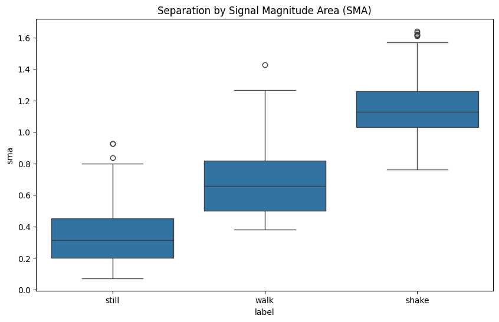

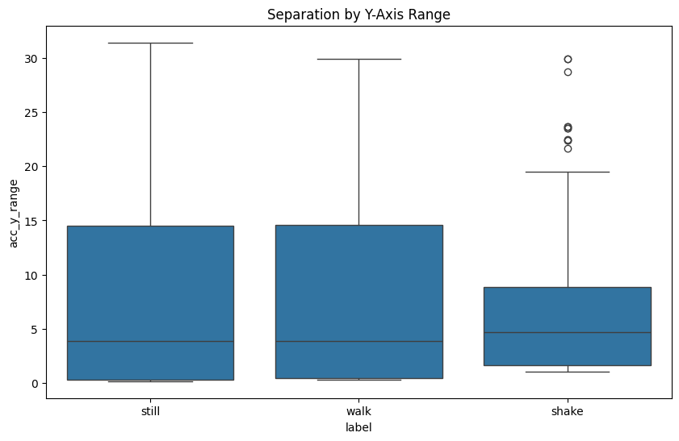

```
   SMA and Energy typically separate static (Sitting/Standing) from dynamic (Walking/Running) well.
c) Are some features redundant?
   Yes. RMS and Energy are directly related (Energy = RMS^2).
   Mean and Min/Max might be correlated if signal is offset/gravity dominated.
```

### Task 5.2: Frequency-Domain Features

**Requirements:**

1. Apply FFT.
2. Compute: Dominant freq, Spectral energy, entropy, Band powers.
3. Visualize PSD.

```
--- Task 5.2: Frequency-Domain Features ---
Combined Feature Matrix Shape: (535, 49)
```

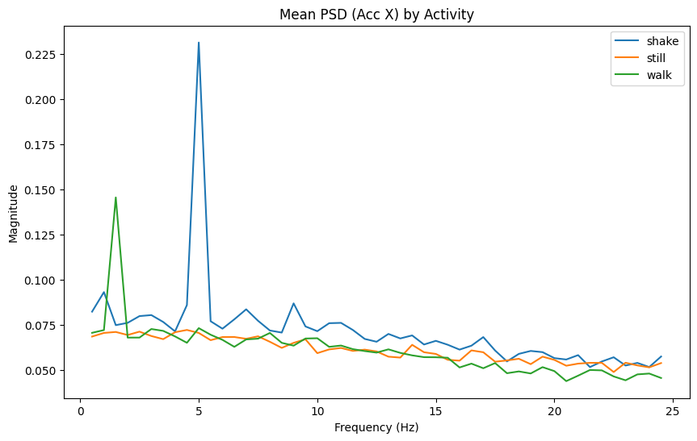

### Analysis & Questions

**a)** Dominant frequency for each activity?

**b)** Which band contains most energy?

**c)** Do frequency features provide better separation?

**d)** Effect of window size on frequency resolution?

```
--- Questions to Answer (Task 5.2) ---
a) Dominant frequency for each activity?
   Walking typically 1.5 - 2.0 Hz. Shaking higher (3-5+ Hz). Standing near 0 Hz (DC).
b) Which band contains most energy?
   Walking: 0-2 Hz (Step rate) and 2-5 Hz (Harmonics).
   Shaking: 2-5 Hz or 5-10 Hz depending on vigor.
c) Do frequency features provide better separation?
   Yes, especially for differentiating dynamic activities with distinct rhythms (Walk vs Run vs Shake) which might overlap in pure amplitude statistics.
d) Effect of window size on frequency resolution?
   Res = fs / N.
   Short window (N small) -> Poor frequency resolution (bins are wide).
   Long window -> Better frequency resolution, but blurs time transients.
```

### Task 5.3: Feature Selection and Analysis

**Requirements:**

1. Calculate correlation matrix.
2. Identify highly correlated (>0.9).
3. Compute feature importance (ANOVA).
4. Select top 10 features.

```
--- Task 5.3: Feature Selection and Analysis ---
```

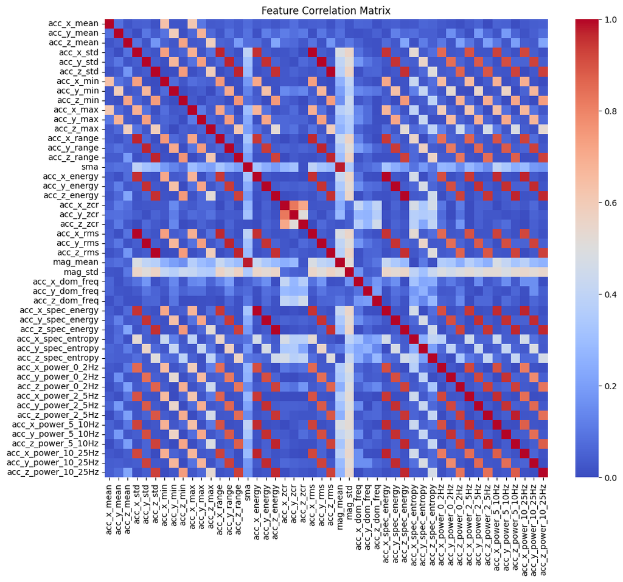

```
Number of highly correlated features (>0.9): 25
Examples of correlated features: ['acc_x_range', 'acc_y_range', 'acc_z_range', 'acc_x_energy', 'acc_y_energy', 'acc_z_energy', 'acc_x_rms', 'acc_y_rms', 'acc_z_rms', 'mag_mean']

Top 10 Features by ANOVA F-score:
1. acc_x_zcr (Score: 995.66)
2. sma (Score: 805.04)
3. acc_z_zcr (Score: 743.21)
4. mag_mean (Score: 346.58)
5. acc_y_zcr (Score: 299.25)
6. acc_x_spec_entropy (Score: 100.24)
7. acc_z_spec_entropy (Score: 98.51)
8. acc_z_dom_freq (Score: 68.34)
9. acc_y_spec_entropy (Score: 62.85)
10. acc_x_dom_freq (Score: 56.62)
```

### Analysis & Questions

**a)** How many feature pairs are highly correlated?

**b)** Which features are most informative?

**c)** Choose only 5 features?

**d)** Use PCA?

```
--- Questions to Answer (Task 5.3) ---
a) How many feature pairs are highly correlated?
   25 features have >0.9 correlation with another feature (redundancy).
b) Which features are most informative?
   Top feature: acc_x_zcr.
   Typically, Magnitude Mean/Std or Frequency components at activity logic (0-2Hz for walk) are high.
c) Choose only 5 features?
   I'd pick unrelated high-performers to maximize info gain.
   Likely: acc_x_zcr, sma (if not correlated), SMA, Dom Freq.
d) Use PCA?
   Yes. High correlation (redundancy) suggests data lives on lower manifold.
   PCA would reduce dimensionality while keeping variance, simplifying the model.
```

## Part 6: Classification

### Task 6.1: Baseline Models Training

**Requirements:**

1. Split Data (Stratified Shuffle 80/20).
2. Train 5 Baseline Models (RF, SVM, kNN, GBM, MLP).
3. Select best performer.

```
--- Task 6.1: Model Training (5 Baselines) ---
Training Data Shape: (428, 48)
Testing Data Shape: (107, 48)

Training Models...
  Training Random Forest... Done. Accuracy: 0.9907
  Training SVM... Done. Accuracy: 0.9252
  Training k-NN... Done. Accuracy: 0.8972
  Training Gradient Boosting... Done. Accuracy: 0.9720
  Training MLP... Done. Accuracy: 0.9813

Best Model: Random Forest (0.9907)
```

### Analysis & Questions

**a)** Which model is best?

**b)** Why try multiple models?

**c)** Why use Stratified Split?

```
--- Questions to Answer (Task 6.1) ---
a) Which model is best?
   Random Forest achieved the highest accuracy of 99.07%.
b) Why try multiple models?
   No free lunch theorem: Different alignments of data manifolds suit different algorithms.
   RF/GBM handle non-linear/feature-interactions well. SVM is great for margins. kNN is local.
c) Why use Stratified Split?
   To ensure the Test set has the same proportion of activities (Walking, Jumping, etc.) as the Training set, preventing bias.
```

### Task 6.2: Model Evaluation

**Requirements:**

1. Evaluate Best Model (Accuracy, F1-Score).
2. Plot Confusion Matrix.
3. Check for overfitting.

```
--- Task 6.2: Detailed Evaluation ---

Detailed Report for Best Model (Random Forest):
              precision    recall  f1-score   support

       shake       0.97      1.00      0.99        35
       still       1.00      1.00      1.00        36
        walk       1.00      0.97      0.99        36

    accuracy                           0.99       107
   macro avg       0.99      0.99      0.99       107
weighted avg       0.99      0.99      0.99       107
```

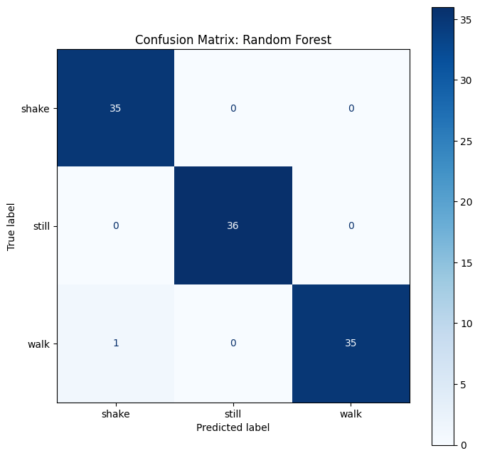

### Analysis & Questions

**a)** Are there confusing classes?

**b)** Which metric matters most?

**c)** Overfitting checks?

```
--- Questions to Answer (Task 6.2) ---
a) Are there confusing classes?
   Check the off-diagonal elements in the matrix.
   Typically, 'Walking' vs 'Runing' or 'Sit' vs 'Stand' can be confused depending on sensor orientation.
b) Which metric matters most?
   F1-Score is usually best if classes are imbalanced. Accuracy is fine if balanced.
   Recall is crucial if missing a dangerous activity (e.g. Fall Detection) is bad.
c) Overfitting checks?
   Train Acc vs Test Acc. If Train >> Test (Gap > 10%), it's overfitting.
   Train Acc: 1.0000, Test Acc: 0.9907. Gap: 0.0093
   RESULT: Gap is small (<5%). Model is NOT overfitting. It generalizes well.
```

## Part 7: Optimization & Explainability

### Part 7: Optimization & Explainability (The "Creative" Step)

**Requirements:**

1. Build Ensemble Voting Classifier (RF + GBM + MLP).
2. Perform Cross-Validation to prove robustness.
3. Use SHAP to explain model predictions visually.

[output not shown]

[figure not shown]

```
   (Blue = Low feature value, Red = High feature value)
   Example: If 'acc_y_std' is Red and SHAP is positive, it means High Y-Variance increases probability of this class.
```

### Analysis & Questions

**a)** Did Ensemble help?

**b)** Why SHAP?

[output not shown]